# Spotify Songs EDA

EXPLORATORY DATA ANALYSIS: INTRODUCTION¶

In this notebook we will take a look at the datasets available in this repository. We will focus on the dataset 1950.csv, which contains:

all the songs from the Spotify's playlist "All out 50s" that you can find here. This playlist collects the most popular and iconic songs from a given decade, in this case it collects the most popular songs from the 50s (1950-1959). for each listed song, a series of attributes are collected in every column of the dataset, as explained in the description of the dataset. The objective is to better understand the data, and study some relationships between the various attributes.

# 1: LOAD PACKAGES AND DATA¶

```python
import pandas as pd
import matplotlib.pyplot as plt
import seaborn as sns

# Load data
spotify_df = pd.read_csv(r"C:\Users\jki\Downloads\sportify songs.csv")

# Show info and description of dataset
print(spotify_df.head(5))
spotify_df.info()
spotify_df.describe()
```

```
   Number                                              title  \
0       1                       Put Your Head On My Shoulder
1       2  Whatever Will Be Will Be (Que Sera Sera) (with...
2       3                           Everybody Loves Somebody
3       4        Take Good Care Of My Baby - 1990 Remastered
4       5                                 A Teenager In Love

                artist        top genre  year  bpm  nrgy  dnce  dB  live  val  \
0            Paul Anka  adult standards  2000  116    34    55  -9    10   47
1            Doris Day  adult standards  1948  177    34    42 -11    72   78
2          Dean Martin  adult standards  2013   81    49    26  -9    34   40
3            Bobby Vee  adult standards  2011   82    43    49 -12    12   66
4  Dion & The Belmonts  adult standards  1959   79    38    56  -9    13   62

   dur  acous  spch  pop
```

[output cut: 27 more lines]

|  | Number | year | bpm | nrgy | dnce | dB | live | val | dur | acous | spch | pop |
| --- | --- | --- | --- | --- | --- | --- | --- | --- | --- | --- | --- | --- |
| count | 73.000000 | 73.000000 | 73.000000 | 73.000000 | 73.000000 | 73.000000 | 73.000000 | 73.000000 | 73.000000 | 73.000000 | 73.000000 | 73.000000 |
| mean | 37.000000 | 1994.205479 | 111.150685 | 34.890411 | 51.027397 | -11.616438 | 18.150685 | 57.589041 | 149.534247 | 73.013699 | 4.191781 | 40.863014 |
| std | 21.217131 | 21.570916 | 28.046425 | 17.411332 | 14.502847 | 3.426328 | 12.005405 | 25.086980 | 22.517945 | 20.130472 | 1.807834 | 10.355239 |
| min | 1.000000 | 1945.000000 | 72.000000 | 6.000000 | 18.000000 | -18.000000 | 2.000000 | 10.000000 | 98.000000 | 4.000000 | 3.000000 | 26.000000 |
| 25% | 19.000000 | 1984.000000 | 87.000000 | 21.000000 | 41.000000 | -15.000000 | 10.000000 | 36.000000 | 135.000000 | 63.000000 | 3.000000 | 33.000000 |
| 50% | 37.000000 | 2000.000000 | 108.000000 | 33.000000 | 52.000000 | -10.000000 | 13.000000 | 57.000000 | 148.000000 | 79.000000 | 3.000000 | 39.000000 |
| 75% | 55.000000 | 2011.000000 | 128.000000 | 44.000000 | 59.000000 | -9.000000 | 24.000000 | 79.000000 | 163.000000 | 87.000000 | 4.000000 | 48.000000 |
| max | 73.000000 | 2019.000000 | 195.000000 | 97.000000 | 88.000000 | -2.000000 | 72.000000 | 99.000000 | 214.000000 | 100.000000 | 11.000000 | 72.000000 |

```python
# Set column Number as index
spotify_df.set_index('Number', inplace=True)

# Drop year column
spotify_df.drop(['year'], axis=1, inplace=True)

# Show updated dataframe
spotify_df.head(5)
```

| Number | title | artist | top genre | bpm | nrgy | dnce | dB | live | val | dur | acous | spch | pop |
| --- | --- | --- | --- | --- | --- | --- | --- | --- | --- | --- | --- | --- | --- |
| 1 | Put Your Head On My Shoulder | Paul Anka | adult standards | 116 | 34 | 55 | -9 | 10 | 47 | 155 | 75 | 3 | 72 |
| 2 | Whatever Will Be Will Be (Que Sera Sera) (with... | Doris Day | adult standards | 177 | 34 | 42 | -11 | 72 | 78 | 123 | 86 | 4 | 62 |
| 3 | Everybody Loves Somebody | Dean Martin | adult standards | 81 | 49 | 26 | -9 | 34 | 40 | 162 | 81 | 4 | 61 |
| 4 | Take Good Care Of My Baby - 1990 Remastered | Bobby Vee | adult standards | 82 | 43 | 49 | -12 | 12 | 66 | 151 | 70 | 6 | 60 |
| 5 | A Teenager In Love | Dion & The Belmonts | adult standards | 79 | 38 | 56 | -9 | 13 | 62 | 158 | 67 | 3 | 60 |

```python
# Find missing values
spotify_df.isna().sum()
```

```
title         0
artist        0
top genre    12
bpm           0
nrgy          0
dnce          0
dB            0
live          0
val           0
dur           0
acous         0
spch          0
pop           0
dtype: int64
```

# 2: GENRE ANALYSIS

First, let's focus on the analysis of the categorical variable top genre. We can show a pie chart of the distribution of the genre. The pie chart shows that more than 50% of the most popular songs in the 50s are adult standards songs (whatever that means, I guess it's pop music). Clearly, we don't have any electronic music, or rap/hip-hop for that matter

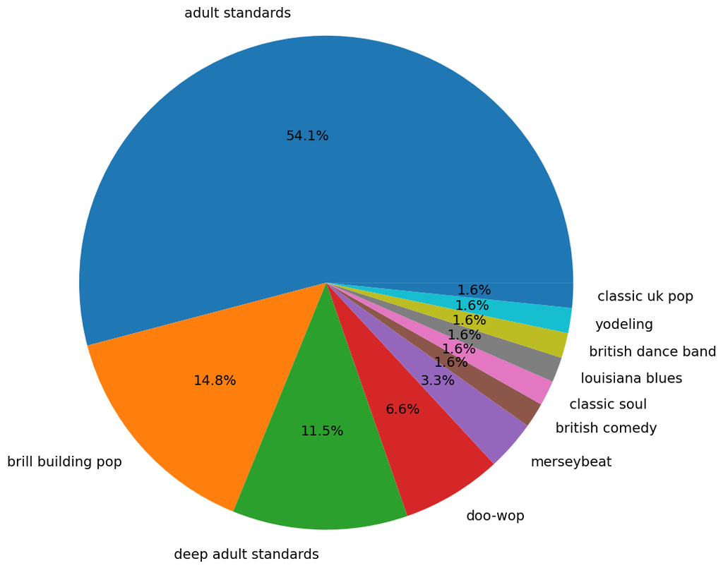

```python
# Find percent of each genre
spotify_df_genre = spotify_df['top genre'].value_counts() / len(spotify_df)
sizes = spotify_df_genre.values.tolist()
labels = spotify_df_genre.index.values.tolist()

# Pie chart for genre
fig1, ax1 = plt.subplots(figsize=(10,10))
ax1.pie(sizes, labels=labels, autopct='%1.1f%%', shadow=False, textprops={'fontsize': 14})
ax1.axis('equal')
plt.show()
```

# 3 BOXPLOT

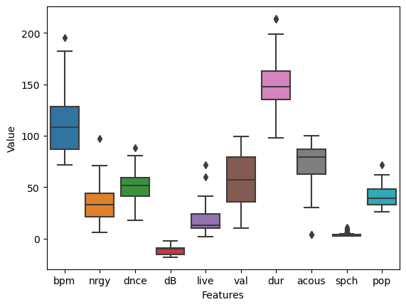

```python
# Plot boxplot (variables only)
sns.boxplot(data=spotify_df.drop(['title', 'artist', 'top genre'], axis=1))
plt.xlabel('Features')
plt.ylabel('Value')
plt.show()
```

# 4 PAIRPLOT

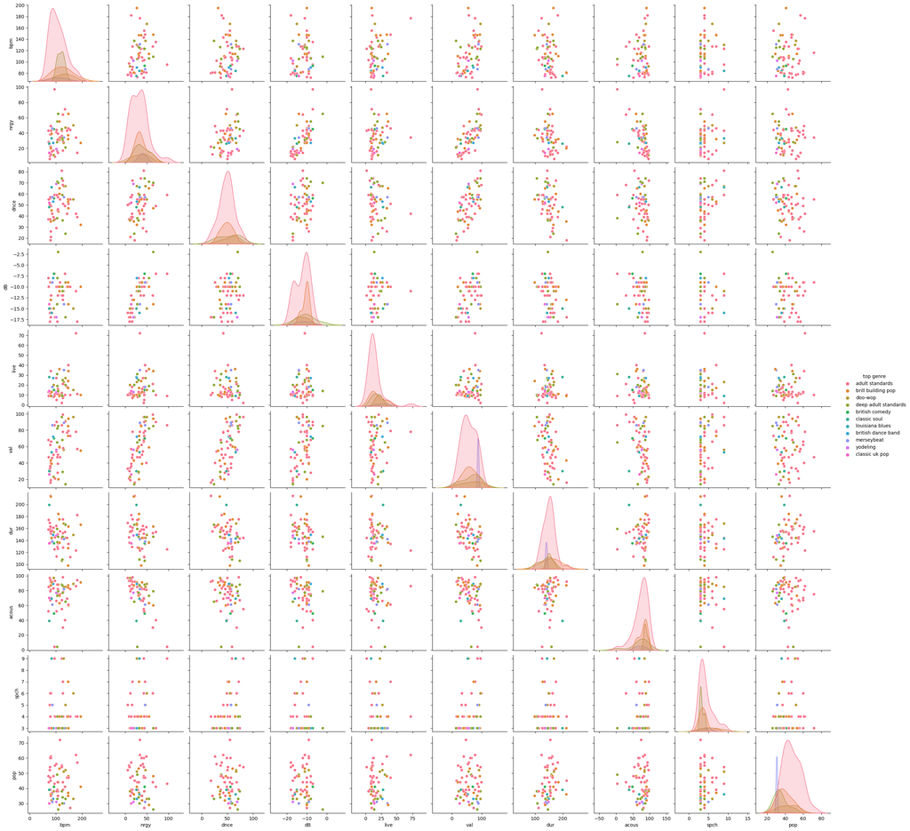

```python
sns.pairplot(data=spotify_df.drop(['title', 'artist'], axis=1), hue='top genre')
plt.show()
```

# 5 CORRELATION MATRIX

the longer the song, the less is has energy, danceability, loudness, liveness. This is understandable in terms of enery and danceability, less so in terms of loudness. the longer the song, the more it is popular. This is somewhat counter-intuitive, since most viral songs are short and catchy, at least nowadays. Almost certainly, music taste has changed from the 50s to today, and will change in the future as well.

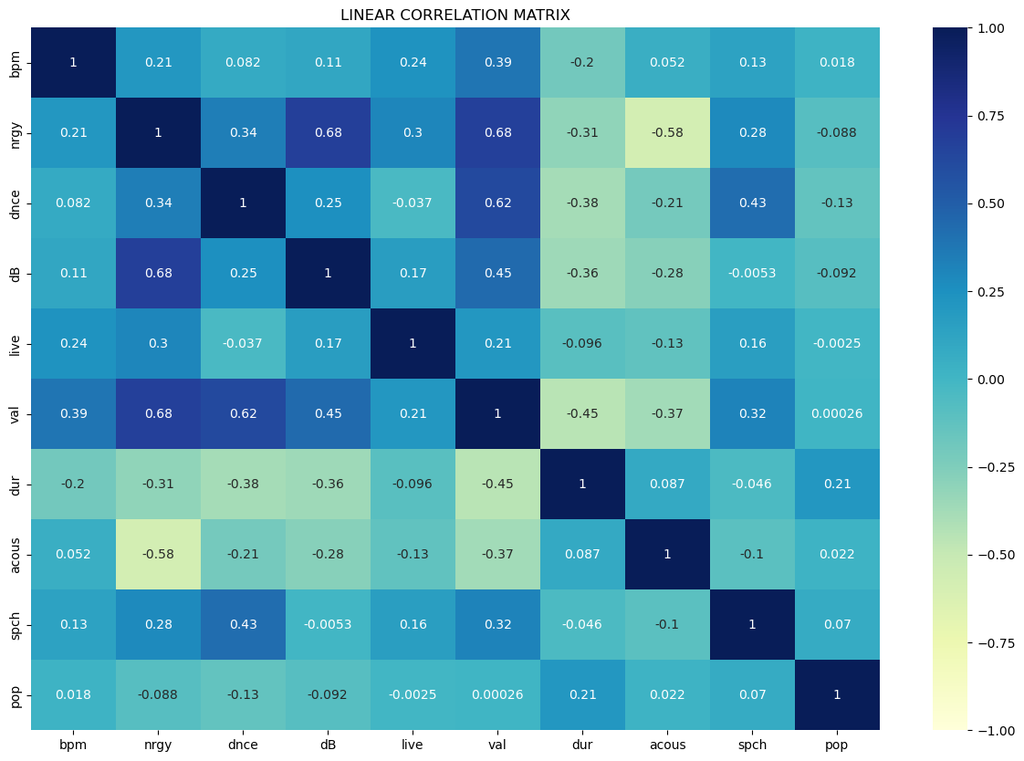

```python
# Plot linear correlation matrix
fig, ax = plt.subplots(figsize=(15,10))
sns.heatmap(spotify_df.corr(), annot=True, cmap='YlGnBu', vmin=-1, vmax=1, center=0, ax=ax)
plt.title('LINEAR CORRELATION MATRIX')
plt.show()
```

This wraps up this notebook. We took a good look at the attributes that define the most popular songs from the 50s.

The steps showed can be applied to the other available datasets, with the intent of tracking how the human music taste changed from the 50s to today.